# Interactions

Sushanta Panda

6/29/2019

```r
data = read.table("https://archive.ics.uci.edu/ml/machine-learning-databases/auto-mpg/auto-mpg.data",
                  quote = "\"",
                  comment.char = "",
                  stringsAsFactors = FALSE)
#Change the column name of the data set autompg
colnames(data) = c("mpg","cyl","disp","hp","wt","acc","year","origin","name")
#remove missing data stored as "?"
data = subset(data,data$hp != "?")
#remove the plymouth, as it causes issues
data = subset(data,data$name != "plymouth reliant")
#Assign the rowname, based on the engine, year and name
rownames(data) = paste(data$cyl,"cylinder",data$year,data$name)
#remove the variable for the name
data = subset(data,select = c("mpg","cyl","disp","hp","wt","acc","year","origin"))
#Change the horsepower from character to name
data$hp = as.numeric(data$hp)
#Creata a dummy variable for foreign vs domestic cars, domestic = 1
data$domestic = as.numeric(data$origin == 1)
#remove the 3 and 5 cylinder cars, as they arr very rare
data = data[data$cyl != 5,]
data = data[data$cyl != 3,]
#the following line would verify the remaining cylinder possibilities are 4,6,8
#unique(data$cyl)
#change cyl to a factor variable
data$cyl = as.factor(data$cyl)
```

```r
str(data)
```

```
## 'data.frame':    383 obs. of  9 variables:
##  $ mpg     : num  18 15 18 16 17 15 14 14 14 15 ...
##  $ cyl     : Factor w/ 3 levels "4","6","8": 3 3 3 3 3 3 3 3 3 3 ...
##  $ disp    : num  307 350 318 304 302 429 454 440 455 390 ...
##  $ hp      : num  130 165 150 150 140 198 220 215 225 190 ...
##  $ wt      : num  3504 3693 3436 3433 3449 ...
##  $ acc     : num  12 11.5 11 12 10.5 10 9 8.5 10 8.5 ...
##  $ year    : int  70 70 70 70 70 70 70 70 70 70 ...
##  $ origin  : int  1 1 1 1 1 1 1 1 1 1 ...
##  $ domestic: num  1 1 1 1 1 1 1 1 1 1 ...
```

$$Y = \beta_0 + \beta_1 x_1 + \beta_2 x_2 + \epsilon$$

where

- $Y$ is `mpg`, the fuel efficieny in miles per gallon
- $x_1$ is `disp`, the displacement in cubic inches
- $x_2$ is `domestic` as described above, is a dummy variable

$$x_2 =
\begin{cases}
1 & \text{Domestic} \\
0 & \text{Foreign}\\
\end{cases}$$

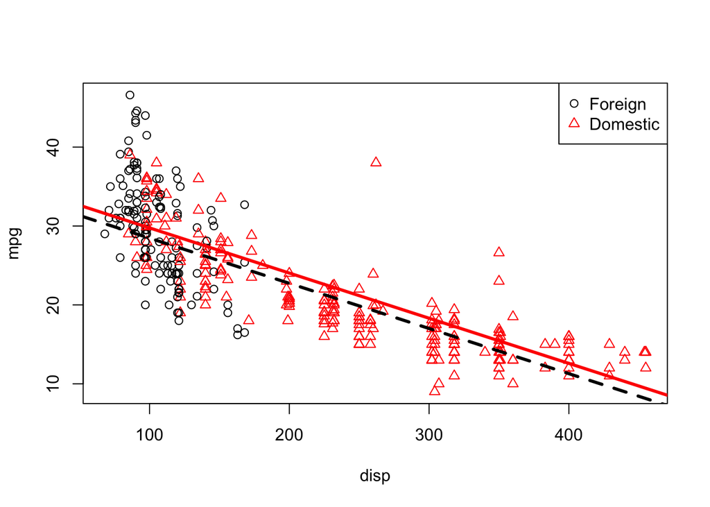

```r
mpg_disp_add = lm(mpg~disp+domestic,data=data)
int_for = summary(mpg_disp_add)$coefficient[1,1]
int_dom = summary(mpg_disp_add)$coefficient[1,1] + summary(mpg_disp_add)$coefficient[3,1]

slope_for = summary(mpg_disp_add)$coefficient[2,1]
slope_dom = summary(mpg_disp_add)$coefficient[2,1]

plot(mpg~disp, data = data,col = domestic + 1,pch = domestic + 1)
abline(int_for,slope_for,lwd=3,col=2,lty=1)
abline(int_dom,slope_dom,lwd=3,col=1,lty=2)
legend("topright",legend=c("Foreign","Domestic"),col=c(1,2),pch=c(1,2))
```

$$Y_i = \beta_0 + \beta_1 x_1 + \beta_2 x_2 + \beta_3 x_1 x_2 + \epsilon$$

For domestic cars, that is $x_2 = 1$, we have
$$Y_i = (\beta_0 + \beta_2) + (\beta_1 +\beta_3 ) x_1 + \epsilon$$

For foreign cars, that is $x_2 = 0$, we have
$$Y_i = \beta_0 + \beta_1 x_1 + \epsilon$$

These two models have both different slopes and interceps

- $\beta_0$ is the average `mpg` for foreign cars when the `disp` is **0**
- $\beta_1$ is the change in average `mpg`, when the `disp` is increased by 1, for **foreign** cars
- $\beta_0 + \beta_2$ is average `mpg` for domestic cars when the `disp` is **0**
- $\beta_1 + \beta_3$ is the change in average `mpg`, when the `disp` is increased by 1, for **domestic** cars

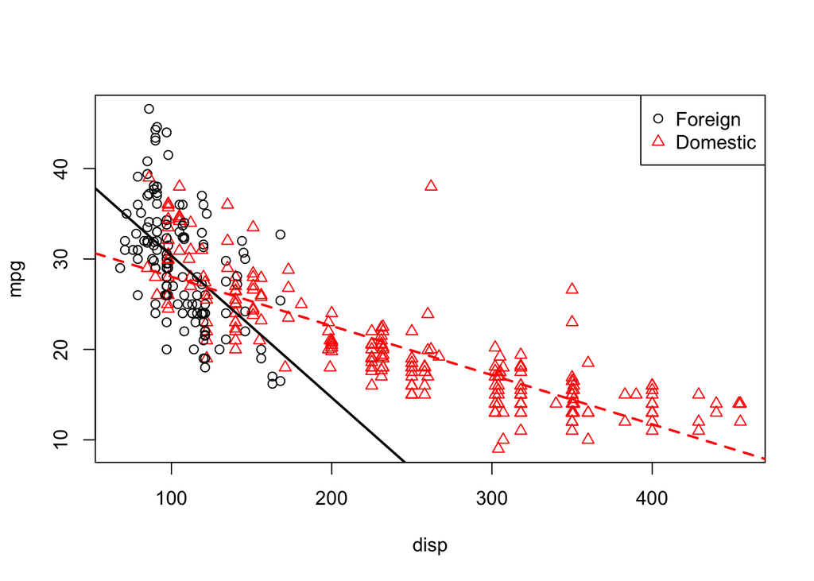

```r
mpg_disp_inter = lm(mpg~disp + domestic + disp:domestic,data=data)
int_for = summary(mpg_disp_inter)$coefficient[1,1]
int_dom = summary(mpg_disp_inter)$coefficient[1,1]+summary(mpg_disp_inter)$coefficient[3,1]

slope_for = summary(mpg_disp_inter)$coefficient[2,1]
slope_dom = summary(mpg_disp_inter)$coefficient[2,1] + summary(mpg_disp_inter)$coefficient[4,1]

plot(mpg~disp,data=data,col=domestic+1,pch=domestic+1)
abline(int_for,slope_for,lwd=2,col=1,lty=1)
abline(int_dom,slope_dom,lwd=2,col=2,lty=2)
legend("topright",legend=c("Foreign","Domestic"),col=c(1,2),pch=c(1,2))
```

# Numeric-Numeric Interaction

$$Y_i = \beta_0 + \beta_1 x_1 + \beta_2 x_2 + \beta_3 x_1 x_2 + \epsilon$$

where

- $Y$ is `mpg`, the fuel efficient in miles per gallon
- $x_1$ is the `disp`, the displacement in cubic inches
- $x_2$ is the `hp`, the horsepower, in foot-pound per square

$$Y_i = \beta_0 + (\beta_1 + \beta_3 x_2) x_1 + \beta_2 x_2 + \epsilon$$

```r
mpg_disp_add_hp = lm(mpg~disp+hp,data=data)
mpg_disp_int_hp = lm(mpg~disp*hp,data=data)

summary(mpg_disp_int_hp)
```

```
##
## Call:
## lm(formula = mpg ~ disp * hp, data = data)
##
## Residuals:
##      Min       1Q   Median       3Q      Max
## -10.7849  -2.3104  -0.5699   2.1453  17.9211
##
## Coefficients:
##               Estimate Std. Error t value Pr(>|t|)
## (Intercept)  5.241e+01  1.523e+00   34.42   <2e-16 ***
## disp        -1.002e-01  6.638e-03  -15.09   <2e-16 ***
## hp          -2.198e-01  1.987e-02  -11.06   <2e-16 ***
## disp:hp      5.658e-04  5.165e-05   10.96   <2e-16 ***
## ---
## Signif. codes:  0 '***' 0.001 '**' 0.01 '*' 0.05 '.' 0.1 ' ' 1
##
## Residual standard error: 3.896 on 379 degrees of freedom
## Multiple R-squared:  0.7554, Adjusted R-squared:  0.7535
## F-statistic: 390.2 on 3 and 379 DF,  p-value: < 2.2e-16
```

$$H_0: \beta_3 = 0, H_1 : \beta_3 \neq 0$$

```r
anova(mpg_disp_add_hp,mpg_disp_int_hp)
```

```
## Analysis of Variance Table
##
## Model 1: mpg ~ disp + hp
## Model 2: mpg ~ disp * hp
##   Res.Df    RSS Df Sum of Sq      F    Pr(>F)
## 1    380 7576.6
## 2    379 5754.2  1    1822.3 120.03 < 2.2e-16 ***
## ---
## Signif. codes:  0 '***' 0.001 '**' 0.01 '*' 0.05 '.' 0.1 ' ' 1
```

$$Y_i = \beta_0 + \beta_1 x_1 + \beta_2 v_2 + \beta_3 v_3 + \epsilon$$
$$v1 =
\begin{cases}
1 & \text{4 Cylinder} \\
0 & \text{Not a 4 Cylinder}
\end{cases}$$

$$v2 =
\begin{cases}
1 & \text{6 Cylinder} \\
0 & \text{Not a 6 Cylinder}
\end{cases}$$

$$v3 =
\begin{cases}
1 & \text{8 Cylinder} \\
0 & \text{Not a 8 Cylinder}
\end{cases}$$
For a 4 Cylinder Engine, $v_2$ and $v_3$ will be **0**
$$Y_i = \beta_0 + \beta_1 x_1 + \epsilon$$

For a 6 Cylinder Engine, $v_2$ = 1 and $v_3$ = **0**
$$Y_i = (\beta_0 + \beta_2) + \beta_1 x_1 + \epsilon$$

For a 8 Cylinder Engine, $v_2$ = 0 and $v_3$ = **1**
$$Y_i = (\beta_0 + \beta_3) + \beta_1 x_1 + \epsilon$$

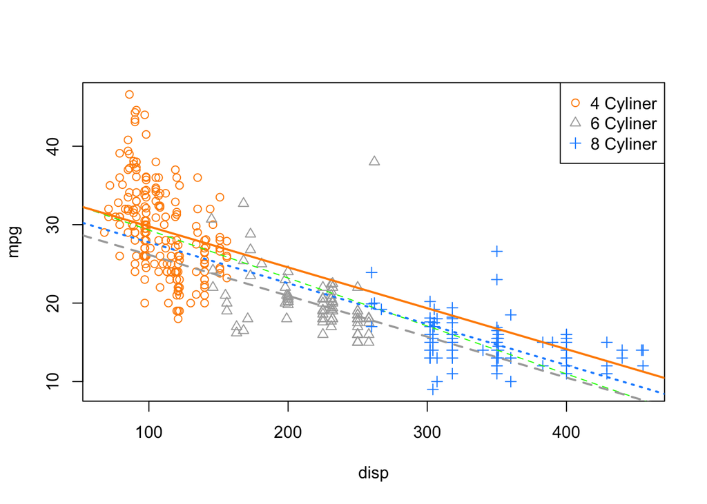

```r
mpg_disp = lm(mpg~disp,data=data)
mpg_disp_add_cyl = lm(mpg~disp+cyl,data=data)
int_4cyl = summary(mpg_disp_add_cyl)$coefficient[1,1]
int_6cyl = summary(mpg_disp_add_cyl)$coefficient[1,1] + summary(mpg_disp_add_cyl)$coefficient[3,1]
int_8cyl = summary(mpg_disp_add_cyl)$coefficient[1,1]+ summary(mpg_disp_add_cyl)$coefficient[4,1]

slope_all_cyl = summary(mpg_disp_add_cyl)$coefficient[2,1]

plot_colours = c("Darkorange","Darkgrey","Dodgerblue")
plot(mpg~disp,data=data,col=plot_colours[cyl],pch=as.numeric(cyl))
abline(mpg_disp,lwd=1,col="green",lty=8)

abline(int_4cyl,slope_all_cyl,lwd=2,col=plot_colours[1],lty=1)
abline(int_6cyl,slope_all_cyl,lwd=2,col=plot_colours[2],lty=2)
abline(int_8cyl,slope_all_cyl,lwd=2,col=plot_colours[3],lty=3)

legend("topright",legend=c("4 Cyliner","6 Cyliner","8 Cyliner"),col=plot_colours,pch=c(1,2,3))
```

Below is the interaction model
$$Y_i = \beta_0 + \beta_1 x + \beta_2 v_2 + \beta_3 v_3 + \gamma_2 x v_2 + \gamma_3 x v_3 + \epsilon$$
For a 4 Cylinder Engine
$$Y_i = \beta_0 + \beta_1 x + \epsilon$$
For a 6 Cylinder Engine
$$Y_i = (\beta_0 + \beta_2) + (\beta_1 + \gamma_2) x + \epsilon$$
For a 8 Cylinder Engine
$$Y_i = (\beta_0 + \beta_3) + (\beta_1 + \gamma_3) x + \epsilon$$

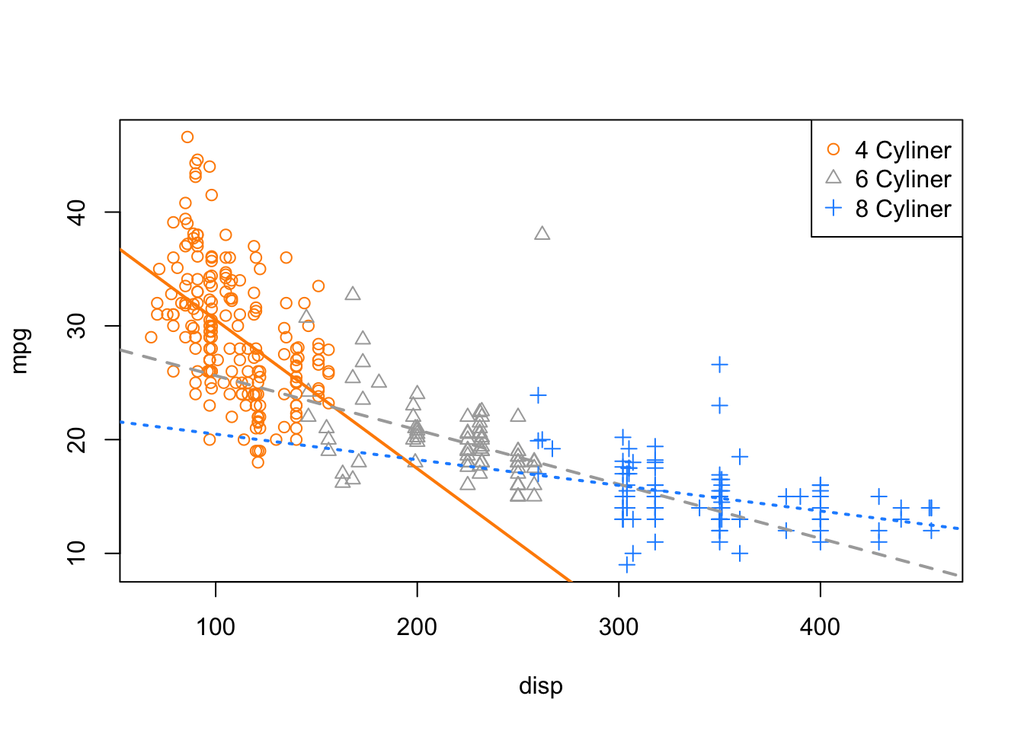

```r
mpg_disp_int_cyl = lm(mpg~disp*cyl,data=data)
int_4cyl = summary(mpg_disp_int_cyl)$coefficient[1,1]
int_6cyl = summary(mpg_disp_int_cyl)$coefficient[1,1] + summary(mpg_disp_int_cyl)$coefficient[3,1]
int_8cyl = summary(mpg_disp_int_cyl)$coefficient[1,1] + summary(mpg_disp_int_cyl)$coefficient[4,1]

slope_4cyl = summary(mpg_disp_int_cyl)$coefficient[2,1]
slope_6cyl = summary(mpg_disp_int_cyl)$coefficient[2,1] + summary(mpg_disp_int_cyl)$coefficient[5,1]
slope_8cyl = summary(mpg_disp_int_cyl)$coefficient[2,1] + summary(mpg_disp_int_cyl)$coefficient[6,1]

plot (mpg~disp,data=data,col=plot_colours[cyl],pch=as.numeric(cyl))
abline(int_4cyl,slope_4cyl,lwd=2,col=plot_colours[1],pch=1,lty=1)
abline(int_6cyl,slope_6cyl,lwd=2,col=plot_colours[2],pch=2,lty=2)
abline(int_8cyl,slope_8cyl,lwd=2,col=plot_colours[3],pch=3,lty=3)
legend("topright",legend=c("4 Cyliner","6 Cyliner","8 Cyliner"),col=plot_colours,pch=c(1,2,3))
```

Now, do the F Test between the Additive Model and Interaction Model, below are the 2 models

$$H_0 : \gamma_2 = \gamma_3 = 0$$

Below is the Additive Model
$$Y_i = \beta_0 + \beta_1 x_1 + \beta_2 v_2 + \beta_3 v_3 + \epsilon$$

Below is the Interaction Model
$$Y_i = \beta_0 + \beta_1 x + \beta_2 v_2 + \beta_3 v_3 + \gamma_2 x v_2 + \gamma_2 x v_3 + \epsilon$$

```r
anova(mpg_disp_add_cyl,mpg_disp_int_cyl)
```

```
## Analysis of Variance Table
##
## Model 1: mpg ~ disp + cyl
## Model 2: mpg ~ disp * cyl
##   Res.Df    RSS Df Sum of Sq      F    Pr(>F)
## 1    379 7299.5
## 2    377 6551.7  2    747.79 21.515 1.419e-09 ***
## ---
## Signif. codes:  0 '***' 0.001 '**' 0.01 '*' 0.05 '.' 0.1 ' ' 1
```